# Prediction of exercise execution

C. Euler

December 4, 2016

# Summary

# Data set

Using devices such as Jawbone Up, Nike FuelBand, and Fitbit it is now possible to collect a large amount of data about personal activity relatively inexpensively. These type of devices are part of the quantified self movement - a group of enthusiasts who take measurements about themselves regularly to improve their health, to find patterns in their behavior, or because they are tech geeks. One thing that people regularly do is quantify how much of a particular activity they do, but they rarely quantify how well they do it. In this project, your goal will be to use data from accelerometers on the belt, forearm, arm, and dumbell of 6 participants. They were asked to perform barbell lifts correctly and incorrectly in 5 different ways. (Source: Coursera Assignment Page)

# Data acquisition and preparation

Before modeling I obtain data and perform a brief analysis as well as data preparation.

## Data acquisition

Data are acquired from the URLs provided in the exercise description.

```r
trainUrl <- "http://d396qusza40orc.cloudfront.net/predmachlearn/pml-training.csv"
testUrl <- "http://d396qusza40orc.cloudfront.net/predmachlearn/pml-testing.csv"
training <- read.csv("D:/Users/ceuler/Documents/2 DataScience/coursera/course_08_week_04/assignment/pml-training.csv",
                     na.strings=c("NA","#DIV/0!","")) # for online change to url(trainUrl)
testing <- read.csv("D:/Users/ceuler/Documents/2 DataScience/coursera/course_08_week_04/assignment/pml-testing.csv",
                    na.strings=c("NA","#DIV/0!","")) # for online source change to url(testUrl)
```

## Data preparation

For data preparation, * I eliminate columns 1 and 2 (the row number and a name), * remove near-zero variance columns, * disregard columns with more than 90% missing values, * and impute the missing values with the mean.

Then I convert the classe variable that has values A, B, C, D and E into numbers one to five and convert to a factor.

Finally, I provide a correlation analysis.

```r
# Remove ID (col 1)
training <- training[-c(1,2)]
inTrain <- createDataPartition(y=training$classe, p=0.6, list=FALSE)
train <- training[inTrain, ]
test <- training[-inTrain, ]

# Removing near zero variance variables
train.NZV <- nearZeroVar(train, saveMetrics=TRUE)
train <- train[-which(colnames(train) %in% row.names(train.NZV)[which(train.NZV$nzv==TRUE)])]

# Find fraction of NAs in each column
train.na_frac <- sapply(train, function(x){length(which(is.na(x)))})/nrow(train)

# Columns are either almost empty or almost always filled. Removing all columns with fraction > 90%
train <- train[-which(train.na_frac>0.9)]

# Do this transformation also for the test set
test <- test[colnames(test) %in% colnames(train)]

# Remove NAs by setting to mean
for (i in 1:(ncol(train)-1)){
  train[which(is.na(train[,i])),i] <- mean(train[,i], na.rm=TRUE)
  test[which(is.na(test[,i])),i] <- mean(test[,i], na.rm=TRUE)
}
```

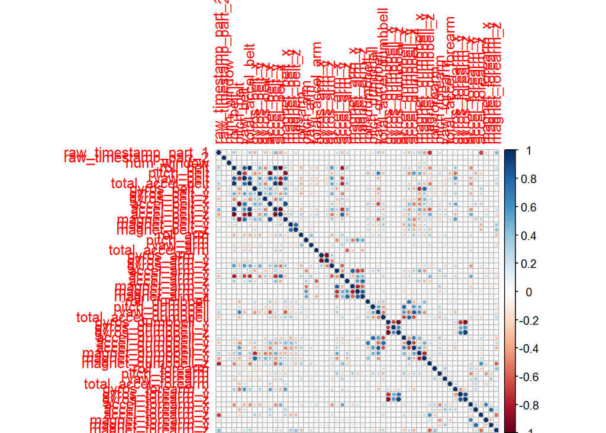

```r
# Convert classe to numeric
train$type <- 0
train$type[which(train$classe=="A")] <- 1
train$type[which(train$classe=="B")] <- 2
train$type[which(train$classe=="C")] <- 3
train$type[which(train$classe=="D")] <- 4
train$type[which(train$classe=="E")] <- 5
train$type <- factor(train$type)

test$type <- 0
test$type[which(test$classe=="A")] <- 1
test$type[which(test$classe=="B")] <- 2
test$type[which(test$classe=="C")] <- 3
test$type[which(test$classe=="D")] <- 4
test$type[which(test$classe=="E")] <- 5
test$type <- factor(test$type)

# Remove classe and user_name
train <- train[-57]
test <- test[-57]

## Correlation analysis
corrplot(cor(rbind(train,test)[-c(3,57)]))
```

# Modeling

```r
mdl_ctree <- train(train$type~., data=train, method="ctree",
                preProcess = c("center", "scale"),
                trControl = trainControl(method="cv"))
pred_ctree <- predict(mdl_ctree, test)
```

## Model 2: Boosted Forest without PCA

```r
mdl_xgb <- train(train$type~., data=train, method="xgbTree",
                 preProcess = c("center", "scale"),
                 trControl = trainControl(method="cv"))
pred_xgb <- predict(mdl_xgb, test)
```

## Model 3: Boosted Forest with PCA

```r
mdl_xgb.pca <- train(train$type~., data=train, method="xgbTree",
                     preProcess = c("center", "scale", "pca"),
                     trControl = trainControl(method="cv"))
pred_xgb.pca <- predict(mdl_xgb.pca, test)
```

```r
# Stack data
stacked_data <- cbind(pred_ctree, pred_xgb, pred_xgb.pca, test$type)

# Train final model using cross validation
mdl_final <- train(stacked_data[,4] ~ stacked_data[,3] + stacked_data[,2] + stacked_data[,1], data=stacked_data,
                   method="xgbTree", trControl = trainControl(method="cv"))
pred_final <- round(predict(mdl_final, stacked_data))
```

# Results

In this section I present the results. First, I compute a number of metrics using the inherent confusionMatrix function and then provide the confusion matrices.

```r
c1 <- confusionMatrix(test$type,pred_ctree)
c2 <- confusionMatrix(test$type,pred_xgb)
c3 <- confusionMatrix(test$type,pred_xgb.pca)
cc <- confusionMatrix(test$type,pred_final)
mdls <- rbind(c1$overall, c2$overall, c3$overall, cc$overall)
row.names(mdls) <-c("Model 1", "Model 2", "Model 3", "Stacked model")
kable(mdls, row.names=TRUE)
```

|  | Accuracy | Kappa | AccuracyLower | AccuracyUpper | AccuracyNull | AccuracyPValue | McnemarPValue |
| --- | --- | --- | --- | --- | --- | --- | --- |
| Model 1 | 0.9761662 | 0.9698501 | 0.9725453 | 0.9794272 | 0.286388 | 0 | NaN |
| Model 2 | 0.9983431 | 0.9979042 | 0.9971683 | 0.9991175 | 0.284986 | 0 | NaN |
| Model 3 | 0.9668621 | 0.9580627 | 0.9626603 | 0.9707123 | 0.288937 | 0 | NaN |
| Stacked model | 0.9984706 | 0.9980654 | 0.9973299 | 0.9992095 | 0.284986 | 0 | NaN |

The above table clearly shows that the stacked model is only slightly better than model 2.

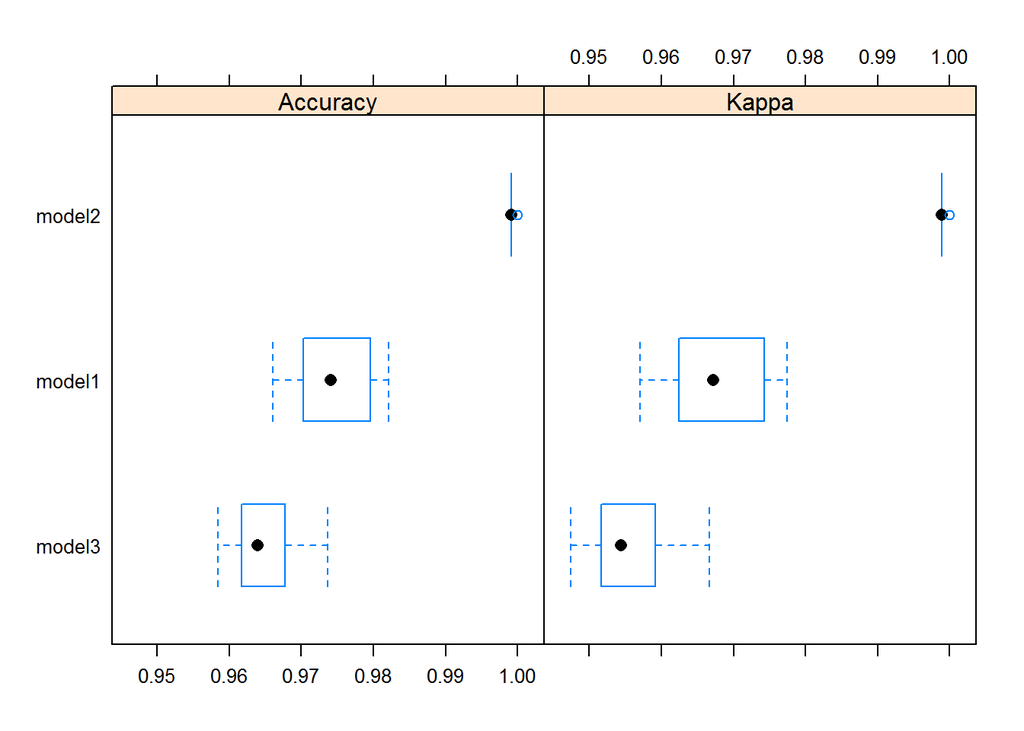

```r
results <- resamples(list(model1=mdl_ctree, model2=mdl_xgb, model3=mdl_xgb.pca))
bwplot(results)
```

This boxplot demonstrates that model 2 is the only model that has a small confidence interval. Since the stacked model consists of both, it naturally choses most of model two’s performance.

## Confusion Matrices

### Model 1

```r
kable(c1$table, row.names=TRUE)
```

|  | 1 | 2 | 3 | 4 | 5 |
| --- | --- | --- | --- | --- | --- |
| 1 | 2226 | 5 | 0 | 0 | 1 |
| 2 | 12 | 1498 | 8 | 0 | 0 |
| 3 | 0 | 6 | 1326 | 27 | 9 |
| 4 | 0 | 0 | 18 | 1241 | 27 |
| 5 | 9 | 0 | 5 | 60 | 1368 |

### Model 2

```r
kable(c2$table, row.names=TRUE)
```

|  | 1 | 2 | 3 | 4 | 5 |
| --- | --- | --- | --- | --- | --- |
| 1 | 2232 | 0 | 0 | 0 | 0 |
| 2 | 4 | 1514 | 0 | 0 | 0 |
| 3 | 0 | 1 | 1367 | 0 | 0 |
| 4 | 0 | 0 | 0 | 1286 | 0 |
| 5 | 0 | 0 | 0 | 8 | 1434 |

### Model 3

```r
kable(c3$table, row.names=TRUE)
```

|  | 1 | 2 | 3 | 4 | 5 |
| --- | --- | --- | --- | --- | --- |
| 1 | 2205 | 17 | 10 | 0 | 0 |
| 2 | 60 | 1425 | 33 | 0 | 0 |
| 3 | 2 | 45 | 1304 | 16 | 1 |
| 4 | 0 | 0 | 45 | 1233 | 8 |
| 5 | 0 | 0 | 2 | 21 | 1419 |

### Stacked model

```r
kable(cc$table, row.names=TRUE)
```

|  | 1 | 2 | 3 | 4 | 5 |
| --- | --- | --- | --- | --- | --- |
| 1 | 2232 | 0 | 0 | 0 | 0 |
| 2 | 4 | 1514 | 0 | 0 | 0 |
| 3 | 0 | 0 | 1368 | 0 | 0 |
| 4 | 0 | 0 | 0 | 1286 | 0 |
| 5 | 0 | 0 | 0 | 8 | 1434 |

# Predict the testing dataset

## Preparation

I prepare the data to have the same columns as the training data and impute using the mean.

```r
# Remove unneccessary columns
testing <- testing[names(testing) %in% names(train)]
# Remove NAs by setting to mean
for (i in 1:(ncol(train)-1)){
  testing[which(is.na(testing[,i])),i] <- mean(testing[,i], na.rm=TRUE)
}
```

## Prediction

```r
setwd("D:/Users/ceuler/Documents/2 DataScience/coursera/course_08_week_04/assignment/")
p1 <- predict(mdl_ctree,testing)
p2 <- predict(mdl_xgb,testing)
p3 <- predict(mdl_xgb.pca,testing)
#p4 <- predict(mdl_final,cbind.data.frame(p1,p2,p3))
write.csv(cbind(dat=testing,pred=p1),"testing_model1.csv", row.names = FALSE)
write.csv(cbind(dat=testing,pred=p2),"testing_model2.csv", row.names = FALSE)
write.csv(cbind(dat=testing,pred=p3),"testing_model3.csv", row.names = FALSE)
```